# Risk Factor Analysis

## Outcome Variable

**Outcome Variable:** swasted

## Predictor Variables

**Intervention Variable:** parity

**Adjustment Set:**

unadjusted

## Stratifying Variables

The analysis was stratified on these variable(s):

- agecat
- studyid
- country

## Data Summary

| agecat | studyid | country | parity | swasted | n_cell | n |
| --- | --- | --- | --- | --- | --- | --- |
| Birth | ki1000304b-SAS-CompFeed | INDIA | 1 | 0 | 39 | 166 |
| Birth | ki1000304b-SAS-CompFeed | INDIA | 1 | 1 | 2 | 166 |
| Birth | ki1000304b-SAS-CompFeed | INDIA | 2 | 0 | 43 | 166 |
| Birth | ki1000304b-SAS-CompFeed | INDIA | 2 | 1 | 1 | 166 |
| Birth | ki1000304b-SAS-CompFeed | INDIA | 3+ | 0 | 79 | 166 |
| Birth | ki1000304b-SAS-CompFeed | INDIA | 3+ | 1 | 2 | 166 |
| Birth | ki1101329-Keneba | GAMBIA | 1 | 0 | 141 | 1292 |
| Birth | ki1101329-Keneba | GAMBIA | 1 | 1 | 1 | 1292 |
| Birth | ki1101329-Keneba | GAMBIA | 2 | 0 | 133 | 1292 |
| Birth | ki1101329-Keneba | GAMBIA | 2 | 1 | 0 | 1292 |
| Birth | ki1101329-Keneba | GAMBIA | 3+ | 0 | 1008 | 1292 |
| Birth | ki1101329-Keneba | GAMBIA | 3+ | 1 | 9 | 1292 |
| Birth | ki1126311-ZVITAMBO | ZIMBABWE | 1 | 0 | 5154 | 12915 |
| Birth | ki1126311-ZVITAMBO | ZIMBABWE | 1 | 1 | 407 | 12915 |
| Birth | ki1126311-ZVITAMBO | ZIMBABWE | 2 | 0 | 3671 | 12915 |
| Birth | ki1126311-ZVITAMBO | ZIMBABWE | 2 | 1 | 211 | 12915 |
| Birth | ki1126311-ZVITAMBO | ZIMBABWE | 3+ | 0 | 3299 | 12915 |
| Birth | ki1126311-ZVITAMBO | ZIMBABWE | 3+ | 1 | 173 | 12915 |
| Birth | ki1135781-COHORTS | GUATEMALA | 1 | 0 | 84 | 756 |
| Birth | ki1135781-COHORTS | GUATEMALA | 1 | 1 | 10 | 756 |
| Birth | ki1135781-COHORTS | GUATEMALA | 2 | 0 | 109 | 756 |
| Birth | ki1135781-COHORTS | GUATEMALA | 2 | 1 | 9 | 756 |
| Birth | ki1135781-COHORTS | GUATEMALA | 3+ | 0 | 503 | 756 |
| Birth | ki1135781-COHORTS | GUATEMALA | 3+ | 1 | 41 | 756 |
| Birth | ki1135781-COHORTS | INDIA | 1 | 0 | 599 | 3855 |
| Birth | ki1135781-COHORTS | INDIA | 1 | 1 | 42 | 3855 |
| Birth | ki1135781-COHORTS | INDIA | 2 | 0 | 941 | 3855 |
| Birth | ki1135781-COHORTS | INDIA | 2 | 1 | 41 | 3855 |
| Birth | ki1135781-COHORTS | INDIA | 3+ | 0 | 2138 | 3855 |
| Birth | ki1135781-COHORTS | INDIA | 3+ | 1 | 94 | 3855 |

[output cut: 132 more lines]

The following strata were considered:

- agecat: 24 months, studyid: ki1017093b-PROVIDE, country: BANGLADESH
- agecat: 24 months, studyid: ki1066203-TanzaniaChild2, country: TANZANIA, UNITED REPUBLIC OF
- agecat: 24 months, studyid: ki1101329-Keneba, country: GAMBIA
- agecat: 24 months, studyid: ki1113344-GMS-Nepal, country: NEPAL
- agecat: 24 months, studyid: ki1126311-ZVITAMBO, country: ZIMBABWE
- agecat: 24 months, studyid: ki1135781-COHORTS, country: GUATEMALA
- agecat: 24 months, studyid: ki1135781-COHORTS, country: INDIA
- agecat: 24 months, studyid: ki1135781-COHORTS, country: PHILIPPINES
- agecat: 24 months, studyid: kiGH5241-JiVitA-3, country: BANGLADESH
- agecat: 6 months, studyid: ki1000304b-SAS-CompFeed, country: INDIA
- agecat: 6 months, studyid: ki1000304b-SAS-FoodSuppl, country: INDIA
- agecat: 6 months, studyid: ki1017093b-PROVIDE, country: BANGLADESH
- agecat: 6 months, studyid: ki1066203-TanzaniaChild2, country: TANZANIA, UNITED REPUBLIC OF
- agecat: 6 months, studyid: ki1101329-Keneba, country: GAMBIA
- agecat: 6 months, studyid: ki1113344-GMS-Nepal, country: NEPAL
- agecat: 6 months, studyid: ki1126311-ZVITAMBO, country: ZIMBABWE
- agecat: 6 months, studyid: ki1135781-COHORTS, country: GUATEMALA
- agecat: 6 months, studyid: ki1135781-COHORTS, country: INDIA
- agecat: 6 months, studyid: ki1135781-COHORTS, country: PHILIPPINES
- agecat: 6 months, studyid: kiGH5241-JiVitA-3, country: BANGLADESH
- agecat: Birth, studyid: ki1000304b-SAS-CompFeed, country: INDIA
- agecat: Birth, studyid: ki1101329-Keneba, country: GAMBIA
- agecat: Birth, studyid: ki1126311-ZVITAMBO, country: ZIMBABWE
- agecat: Birth, studyid: ki1135781-COHORTS, country: GUATEMALA
- agecat: Birth, studyid: ki1135781-COHORTS, country: INDIA
- agecat: Birth, studyid: ki1135781-COHORTS, country: PHILIPPINES
- agecat: Birth, studyid: kiGH5241-JiVitA-3, country: BANGLADESH

### Dropped Strata

Some strata were dropped due to rare outcomes:

- agecat: Birth, studyid: ki1000304b-SAS-CompFeed, country: INDIA
- agecat: Birth, studyid: ki1101329-Keneba, country: GAMBIA
- agecat: 6 months, studyid: ki1000304b-SAS-FoodSuppl, country: INDIA
- agecat: 6 months, studyid: ki1017093b-PROVIDE, country: BANGLADESH
- agecat: 6 months, studyid: ki1066203-TanzaniaChild2, country: TANZANIA, UNITED REPUBLIC OF
- agecat: 6 months, studyid: ki1101329-Keneba, country: GAMBIA
- agecat: 6 months, studyid: ki1113344-GMS-Nepal, country: NEPAL
- agecat: 6 months, studyid: ki1135781-COHORTS, country: GUATEMALA
- agecat: 6 months, studyid: ki1135781-COHORTS, country: PHILIPPINES
- agecat: 24 months, studyid: ki1017093b-PROVIDE, country: BANGLADESH
- agecat: 24 months, studyid: ki1066203-TanzaniaChild2, country: TANZANIA, UNITED REPUBLIC OF
- agecat: 24 months, studyid: ki1101329-Keneba, country: GAMBIA
- agecat: 24 months, studyid: ki1113344-GMS-Nepal, country: NEPAL
- agecat: 24 months, studyid: ki1135781-COHORTS, country: GUATEMALA
- agecat: 24 months, studyid: ki1135781-COHORTS, country: INDIA
- agecat: 24 months, studyid: ki1135781-COHORTS, country: PHILIPPINES

## Methods Detail

We’re interested in the causal parameters $E[Y_a]$ for all values of $a \in \mathcal{A}$. These parameters represent the mean outcome if, possibly contrary to fact, we intervened to set all units to have $A=a$. Under the randomization and positivity assumptions, these are identified by the statistical parameters $\psi_a=E_W[E_{Y|A,W}(Y|A=a,W)]$. In addition, we’re interested in the mean of $Y$, $E[Y]$ under no intervention (the observed mean). We will estimate these parameters by using SuperLearner to fit the relevant likelihood factors – $E_{Y|A,W}(Y|A=a,W)$ and $p(A=a|W)$, and then updating our likelihood fit using a joint TMLE.

For unadjusted analyses ($W=\{\}$), initial likelihoods were estimated using Lrnr_glm to estimate the simple $E(Y|A)$ and Lrnr_mean to estimate $p(A)$. For adjusted analyses, a small library containing Lrnr_glmnet, Lrnr_xgboost, and Lrnr_mean was used.

Having estimated these parameters, we will then use the delta method to estimate relative risks and attributable risks relative to a prespecified baseline level of $A$.

# Results Detail

## Results Plots

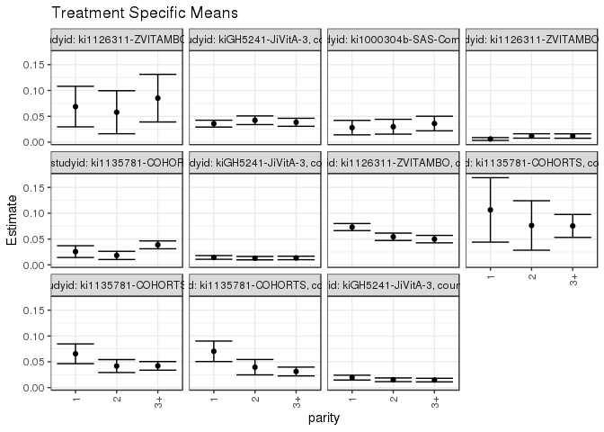

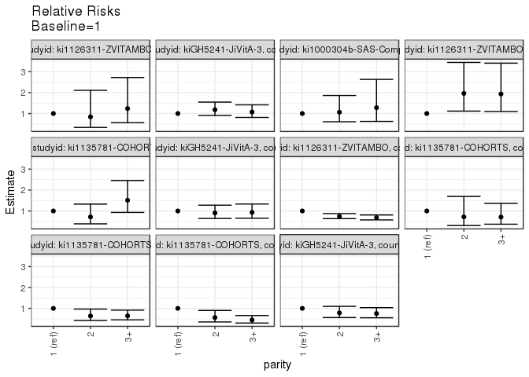

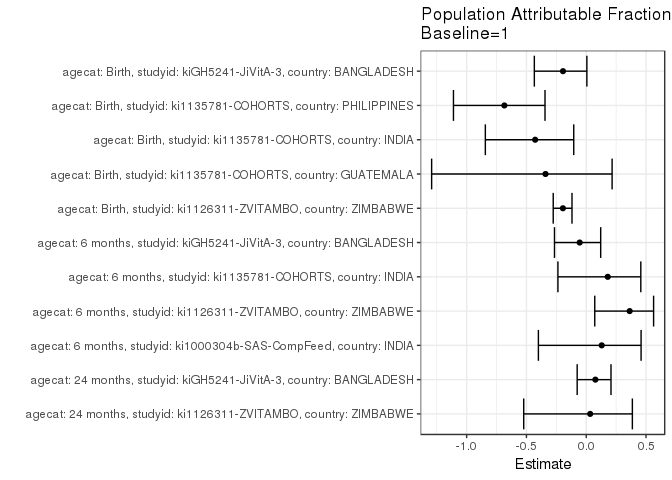

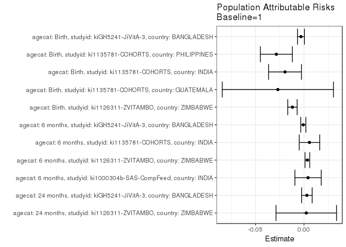

## Results Table

### Parameter: TSM

| agecat | studyid | country | intervention_level | baseline_level | estimate | ci_lower | ci_upper |
| --- | --- | --- | --- | --- | --- | --- | --- |
| Birth | ki1126311-ZVITAMBO | ZIMBABWE | 1 | NA | 0.0731883 | 0.0663428 | 0.0800338 |
| Birth | ki1126311-ZVITAMBO | ZIMBABWE | 2 | NA | 0.0543534 | 0.0472214 | 0.0614855 |
| Birth | ki1126311-ZVITAMBO | ZIMBABWE | 3+ | NA | 0.0498272 | 0.0425893 | 0.0570650 |
| Birth | ki1135781-COHORTS | GUATEMALA | 1 | NA | 0.1063830 | 0.0440119 | 0.1687541 |
| Birth | ki1135781-COHORTS | GUATEMALA | 2 | NA | 0.0762712 | 0.0283479 | 0.1241945 |
| Birth | ki1135781-COHORTS | GUATEMALA | 3+ | NA | 0.0753676 | 0.0531697 | 0.0975656 |
| Birth | ki1135781-COHORTS | INDIA | 1 | NA | 0.0655226 | 0.0463644 | 0.0846809 |
| Birth | ki1135781-COHORTS | INDIA | 2 | NA | 0.0417515 | 0.0292396 | 0.0542634 |
| Birth | ki1135781-COHORTS | INDIA | 3+ | NA | 0.0421147 | 0.0337811 | 0.0504483 |
| Birth | ki1135781-COHORTS | PHILIPPINES | 1 | NA | 0.0703125 | 0.0505010 | 0.0901240 |
| Birth | ki1135781-COHORTS | PHILIPPINES | 2 | NA | 0.0395738 | 0.0246639 | 0.0544838 |
| Birth | ki1135781-COHORTS | PHILIPPINES | 3+ | NA | 0.0312110 | 0.0226945 | 0.0397275 |
| Birth | kiGH5241-JiVitA-3 | BANGLADESH | 1 | NA | 0.0193310 | 0.0146704 | 0.0239917 |
| Birth | kiGH5241-JiVitA-3 | BANGLADESH | 2 | NA | 0.0151652 | 0.0115989 | 0.0187315 |
| Birth | kiGH5241-JiVitA-3 | BANGLADESH | 3+ | NA | 0.0145972 | 0.0111143 | 0.0180802 |
| 6 months | ki1000304b-SAS-CompFeed | INDIA | 1 | NA | 0.0280612 | 0.0140579 | 0.0420646 |
| 6 months | ki1000304b-SAS-CompFeed | INDIA | 2 | NA | 0.0298013 | 0.0154373 | 0.0441654 |
| 6 months | ki1000304b-SAS-CompFeed | INDIA | 3+ | NA | 0.0359375 | 0.0218263 | 0.0500487 |
| 6 months | ki1126311-ZVITAMBO | ZIMBABWE | 1 | NA | 0.0060883 | 0.0034280 | 0.0087486 |
| 6 months | ki1126311-ZVITAMBO | ZIMBABWE | 2 | NA | 0.0119332 | 0.0076883 | 0.0161780 |
| 6 months | ki1126311-ZVITAMBO | ZIMBABWE | 3+ | NA | 0.0117695 | 0.0075109 | 0.0160280 |
| 6 months | ki1135781-COHORTS | INDIA | 1 | NA | 0.0256410 | 0.0142591 | 0.0370230 |
| 6 months | ki1135781-COHORTS | INDIA | 2 | NA | 0.0182983 | 0.0103516 | 0.0262449 |
| 6 months | ki1135781-COHORTS | INDIA | 3+ | NA | 0.0387597 | 0.0311172 | 0.0464022 |
| 6 months | kiGH5241-JiVitA-3 | BANGLADESH | 1 | NA | 0.0143975 | 0.0108050 | 0.0179899 |
| 6 months | kiGH5241-JiVitA-3 | BANGLADESH | 2 | NA | 0.0130167 | 0.0097097 | 0.0163237 |
| 6 months | kiGH5241-JiVitA-3 | BANGLADESH | 3+ | NA | 0.0134014 | 0.0100039 | 0.0167989 |
| 24 months | ki1126311-ZVITAMBO | ZIMBABWE | 1 | NA | 0.0687500 | 0.0294970 | 0.1080030 |
| 24 months | ki1126311-ZVITAMBO | ZIMBABWE | 2 | NA | 0.0578512 | 0.0162040 | 0.0994985 |
| 24 months | ki1126311-ZVITAMBO | ZIMBABWE | 3+ | NA | 0.0851064 | 0.0389937 | 0.1312190 |
| 24 months | kiGH5241-JiVitA-3 | BANGLADESH | 1 | NA | 0.0357821 | 0.0291228 | 0.0424415 |
| 24 months | kiGH5241-JiVitA-3 | BANGLADESH | 2 | NA | 0.0422826 | 0.0339183 | 0.0506468 |
| 24 months | kiGH5241-JiVitA-3 | BANGLADESH | 3+ | NA | 0.0383703 | 0.0306122 | 0.0461283 |

### Parameter: E(Y)

| agecat | studyid | country | intervention_level | baseline_level | estimate | ci_lower | ci_upper |
| --- | --- | --- | --- | --- | --- | --- | --- |
| Birth | ki1126311-ZVITAMBO | ZIMBABWE | NA | NA | 0.0612466 | 0.0571111 | 0.0653822 |
| Birth | ki1135781-COHORTS | GUATEMALA | NA | NA | 0.0793651 | 0.0600839 | 0.0986462 |
| Birth | ki1135781-COHORTS | INDIA | NA | NA | 0.0459144 | 0.0393065 | 0.0525222 |
| Birth | ki1135781-COHORTS | PHILIPPINES | NA | NA | 0.0417385 | 0.0344572 | 0.0490198 |
| Birth | kiGH5241-JiVitA-3 | BANGLADESH | NA | NA | 0.0161866 | 0.0138216 | 0.0185515 |
| 6 months | ki1000304b-SAS-CompFeed | INDIA | NA | NA | 0.0322339 | 0.0235219 | 0.0409459 |
| 6 months | ki1126311-ZVITAMBO | ZIMBABWE | NA | NA | 0.0095607 | 0.0074624 | 0.0116590 |
| 6 months | ki1135781-COHORTS | INDIA | NA | NA | 0.0312719 | 0.0260599 | 0.0364838 |
| 6 months | kiGH5241-JiVitA-3 | BANGLADESH | NA | NA | 0.0136505 | 0.0115778 | 0.0157231 |
| 24 months | ki1126311-ZVITAMBO | ZIMBABWE | NA | NA | 0.0710900 | 0.0465431 | 0.0956370 |
| 24 months | kiGH5241-JiVitA-3 | BANGLADESH | NA | NA | 0.0387435 | 0.0344172 | 0.0430697 |

### Parameter: RR

| agecat | studyid | country | intervention_level | baseline_level | estimate | ci_lower | ci_upper |
| --- | --- | --- | --- | --- | --- | --- | --- |
| Birth | ki1126311-ZVITAMBO | ZIMBABWE | 1 | 1 | 1.0000000 | 1.0000000 | 1.0000000 |
| Birth | ki1126311-ZVITAMBO | ZIMBABWE | 2 | 1 | 0.7426521 | 0.6321253 | 0.8725044 |
| Birth | ki1126311-ZVITAMBO | ZIMBABWE | 3+ | 1 | 0.6808084 | 0.5727868 | 0.8092017 |
| Birth | ki1135781-COHORTS | GUATEMALA | 1 | 1 | 1.0000000 | 1.0000000 | 1.0000000 |
| Birth | ki1135781-COHORTS | GUATEMALA | 2 | 1 | 0.7169492 | 0.3035745 | 1.6932122 |
| Birth | ki1135781-COHORTS | GUATEMALA | 3+ | 1 | 0.7084559 | 0.3675932 | 1.3653943 |
| Birth | ki1135781-COHORTS | INDIA | 1 | 1 | 1.0000000 | 1.0000000 | 1.0000000 |
| Birth | ki1135781-COHORTS | INDIA | 2 | 1 | 0.6372078 | 0.4192258 | 0.9685325 |
| Birth | ki1135781-COHORTS | INDIA | 3+ | 1 | 0.6427505 | 0.4515567 | 0.9148976 |
| Birth | ki1135781-COHORTS | PHILIPPINES | 1 | 1 | 1.0000000 | 1.0000000 | 1.0000000 |
| Birth | ki1135781-COHORTS | PHILIPPINES | 2 | 1 | 0.5628277 | 0.3516036 | 0.9009436 |
| Birth | ki1135781-COHORTS | PHILIPPINES | 3+ | 1 | 0.4438896 | 0.2998677 | 0.6570829 |
| Birth | kiGH5241-JiVitA-3 | BANGLADESH | 1 | 1 | 1.0000000 | 1.0000000 | 1.0000000 |
| Birth | kiGH5241-JiVitA-3 | BANGLADESH | 2 | 1 | 0.7845005 | 0.5610148 | 1.0970139 |
| Birth | kiGH5241-JiVitA-3 | BANGLADESH | 3+ | 1 | 0.7551194 | 0.5507635 | 1.0352996 |
| 6 months | ki1000304b-SAS-CompFeed | INDIA | 1 | 1 | 1.0000000 | 1.0000000 | 1.0000000 |
| 6 months | ki1000304b-SAS-CompFeed | INDIA | 2 | 1 | 1.0620108 | 0.6052683 | 1.8634168 |
| 6 months | ki1000304b-SAS-CompFeed | INDIA | 3+ | 1 | 1.2806818 | 0.6228782 | 2.6331726 |
| 6 months | ki1126311-ZVITAMBO | ZIMBABWE | 1 | 1 | 1.0000000 | 1.0000000 | 1.0000000 |
| 6 months | ki1126311-ZVITAMBO | ZIMBABWE | 2 | 1 | 1.9600236 | 1.1157406 | 3.4431771 |
| 6 months | ki1126311-ZVITAMBO | ZIMBABWE | 3+ | 1 | 1.9331369 | 1.0961762 | 3.4091401 |
| 6 months | ki1135781-COHORTS | INDIA | 1 | 1 | 1.0000000 | 1.0000000 | 1.0000000 |
| 6 months | ki1135781-COHORTS | INDIA | 2 | 1 | 0.7136322 | 0.3835092 | 1.3279238 |
| 6 months | ki1135781-COHORTS | INDIA | 3+ | 1 | 1.5116279 | 0.9300370 | 2.4569119 |
| 6 months | kiGH5241-JiVitA-3 | BANGLADESH | 1 | 1 | 1.0000000 | 1.0000000 | 1.0000000 |
| 6 months | kiGH5241-JiVitA-3 | BANGLADESH | 2 | 1 | 0.9040954 | 0.6405163 | 1.2761403 |
| 6 months | kiGH5241-JiVitA-3 | BANGLADESH | 3+ | 1 | 0.9308149 | 0.6505758 | 1.3317686 |
| 24 months | ki1126311-ZVITAMBO | ZIMBABWE | 1 | 1 | 1.0000000 | 1.0000000 | 1.0000000 |
| 24 months | ki1126311-ZVITAMBO | ZIMBABWE | 2 | 1 | 0.8414726 | 0.3357357 | 2.1090285 |
| 24 months | ki1126311-ZVITAMBO | ZIMBABWE | 3+ | 1 | 1.2379110 | 0.5634392 | 2.7197677 |
| 24 months | kiGH5241-JiVitA-3 | BANGLADESH | 1 | 1 | 1.0000000 | 1.0000000 | 1.0000000 |
| 24 months | kiGH5241-JiVitA-3 | BANGLADESH | 2 | 1 | 1.1816669 | 0.9032678 | 1.5458723 |
| 24 months | kiGH5241-JiVitA-3 | BANGLADESH | 3+ | 1 | 1.0723297 | 0.8131046 | 1.4141982 |

### Parameter: PAR

| agecat | studyid | country | intervention_level | baseline_level | estimate | ci_lower | ci_upper |
| --- | --- | --- | --- | --- | --- | --- | --- |
| Birth | ki1126311-ZVITAMBO | ZIMBABWE | 1 | NA | -0.0119417 | -0.0168005 | -0.0070828 |
| Birth | ki1135781-COHORTS | GUATEMALA | 1 | NA | -0.0270179 | -0.0844158 | 0.0303800 |
| Birth | ki1135781-COHORTS | INDIA | 1 | NA | -0.0196082 | -0.0365977 | -0.0026188 |
| Birth | ki1135781-COHORTS | PHILIPPINES | 1 | NA | -0.0285740 | -0.0450729 | -0.0120751 |
| Birth | kiGH5241-JiVitA-3 | BANGLADESH | 1 | NA | -0.0031444 | -0.0067388 | 0.0004500 |
| 6 months | ki1000304b-SAS-CompFeed | INDIA | 1 | NA | 0.0041727 | -0.0094235 | 0.0177689 |
| 6 months | ki1126311-ZVITAMBO | ZIMBABWE | 1 | NA | 0.0034724 | 0.0010532 | 0.0058917 |
| 6 months | ki1135781-COHORTS | INDIA | 1 | NA | 0.0056309 | -0.0049478 | 0.0162095 |
| 6 months | kiGH5241-JiVitA-3 | BANGLADESH | 1 | NA | -0.0007470 | -0.0033843 | 0.0018902 |
| 24 months | ki1126311-ZVITAMBO | ZIMBABWE | 1 | NA | 0.0023400 | -0.0288845 | 0.0335646 |
| 24 months | kiGH5241-JiVitA-3 | BANGLADESH | 1 | NA | 0.0029613 | -0.0025173 | 0.0084400 |

### Parameter: PAF

| agecat | studyid | country | intervention_level | baseline_level | estimate | ci_lower | ci_upper |
| --- | --- | --- | --- | --- | --- | --- | --- |
| Birth | ki1126311-ZVITAMBO | ZIMBABWE | 1 | NA | -0.1949767 | -0.2760114 | -0.1190882 |
| Birth | ki1135781-COHORTS | GUATEMALA | 1 | NA | -0.3404255 | -1.2928794 | 0.2163824 |
| Birth | ki1135781-COHORTS | INDIA | 1 | NA | -0.4270605 | -0.8437543 | -0.1045406 |
| Birth | ki1135781-COHORTS | PHILIPPINES | 1 | NA | -0.6845945 | -1.1103485 | -0.3447346 |
| Birth | kiGH5241-JiVitA-3 | BANGLADESH | 1 | NA | -0.1942611 | -0.4340124 | 0.0054064 |
| 6 months | ki1000304b-SAS-CompFeed | INDIA | 1 | NA | 0.1294495 | -0.4000328 | 0.4586853 |
| 6 months | ki1126311-ZVITAMBO | ZIMBABWE | 1 | NA | 0.3631967 | 0.0712412 | 0.5633759 |
| 6 months | ki1135781-COHORTS | INDIA | 1 | NA | 0.1800612 | -0.2367681 | 0.4564061 |
| 6 months | kiGH5241-JiVitA-3 | BANGLADESH | 1 | NA | -0.0547266 | -0.2654535 | 0.1209095 |
| 24 months | ki1126311-ZVITAMBO | ZIMBABWE | 1 | NA | 0.0329167 | -0.5228379 | 0.3858505 |
| 24 months | kiGH5241-JiVitA-3 | BANGLADESH | 1 | NA | 0.0764339 | -0.0757538 | 0.2070915 |